# Campaign outcome prediction for Bank marketing

Vishal Gupta & Vishu Agarwal

## Goal

To build a model using current campaign, past campaign and customer information to predict whether a consumer is going to subscribe term deposit once the campaign is done. An initial description of the data is a below -

```
## [1] 5278   53
```

```
##   X job_type_blue.collar job_type_entrepreneur job_type_housemaid
## 1 0                    0                     0                  0
## 2 1                    0                     1                  0
## 3 2                    0                     0                  0
## 4 3                    0                     0                  0
## 5 4                    0                     0                  0
## 6 5                    0                     0                  0
##   job_type_management job_type_retired job_type_self.employed job_type_services
## 1                   0                0                      0                 0
## 2                   0                0                      0                 0
## 3                   0                0                      0                 0
## 4                   1                0                      0                 0
## 5                   0                0                      0                 0
## 6                   1                0                      0                 0
##   job_type_student job_type_technician job_type_unemployed job_type_unknown
```

[output cut: 90 more lines]

Data contains raw features, with and without transformation, as well as one hot encoded variables to ensure no more transformation is required at any later stages. Cyclicity for day of the month and month of the year is created to ensure correct representation of the information.

## Modeling

Due to high number of variables in the dataset, first a few formulation will be tried out to set up the baseline and understand the importance of variable in prediction. Further improvements and adjustment can be based on the performance and outcome of each model.

**Possible models**

*1. Baseline*

term_deposit_subscribed ~ job_type + marital + education + default + housing_loan + personal_loan + communication_type + prev_campaign_outcome + prev_campaign_contact + balance + last_contact_duration + num_contacts_in_campaign + num_contacts_prev_campaign + month + day_of_month + customer_age

*2. Transformed variables - balance indicator and log transformed*

term_deposit_subscribed ~ job_type + marital + education + default + housing_loan + personal_loan + communication_type + prev_campaign_outcome + prev_campaign_contact + balance_ind + log_balance + log_last_contact_duration + log_num_contacts_in_campaign + log_num_contacts_prev_campaign + month + day_of_month + customer_age

*3. Adding Cyclicity*

term_deposit_subscribed ~ job_type + marital + education + default + housing_loan + personal_loan + communication_type + prev_campaign_outcome + prev_campaign_contact + balance_ind + log_balance + log_last_contact_duration + log_num_contacts_in_campaign + log_num_contacts_prev_campaign + month_sin + month_cos + day_of_month_sin + day_of_month_cos + customer_age

*4. (i) Adding random effects - job_type*

term_deposit_subscribed ~ marital + education + default + housing_loan + personal_loan + communication_type + prev_campaign_outcome + prev_campaign_contact + balance_ind + log_balance + log_last_contact_duration + log_num_contacts_in_campaign + log_num_contacts_prev_campaign + month_sin + month_cos + day_of_month_sin + day_of_month_cos + customer_age | job_type

*4. (ii) Adding random effects - marital*

term_deposit_subscribed ~ job_type + education + default + housing_loan + personal_loan + communication_type + prev_campaign_outcome + prev_campaign_contact + balance_ind + log_balance + log_last_contact_duration + log_num_contacts_in_campaign + log_num_contacts_prev_campaign + month_sin + month_cos + day_of_month_sin + day_of_month_cos + customer_age | marital

*4. (iii) Adding random effects - education*

term_deposit_subscribed ~ job_type + marital + default + housing_loan + personal_loan + communication_type + prev_campaign_outcome + prev_campaign_contact + balance_ind + log_balance + log_last_contact_duration + log_num_contacts_in_campaign + log_num_contacts_prev_campaign + month_sin + month_cos + day_of_month_sin + day_of_month_cos + customer_age | education

**Evaluation Criteria**

We want to focus more on the customer who are more likely to create a term deposit after the campaign, as it can help identify the attributes in a customer that can make future campaigns more effective. Accuracy, for this purpose, might not be accuracy as we have a unbalanced classes case where most of the customer (>80%) dont subscribe the term deposit. *Recall (sensitivity or true positive rate) will be the primary metrics* as it evaluate the model on reducing false negative (where customer actually made a term deposit but model predicted otherwise). *Second metric of focus will be Precision*, that evaluates false positive for model performance, since they are very less customer that subscribe term deposit, predicting them as positive will not increase the campaign load significantly. Also, these can be the customers that have the potential to subscribe the term deposit in future campaigns.

**1. Baseline - logistic regression with raw inputs**

```
##
## Call:
## glm(formula = term_deposit_subscribed ~ job_type + marital +
##     education + default + housing_loan + personal_loan + communication_type +
##     prev_campaign_outcome + prev_campaign_contact + balance +
##     last_contact_duration + num_contacts_in_campaign + num_contacts_prev_campaign +
##     month + day_of_month + customer_age, family = binomial(link = "logit"),
##     data = train)
##
## Deviance Residuals:
##     Min       1Q   Median       3Q      Max
## -5.3779  -0.5665  -0.0139   0.5609   3.2238
##
## Coefficients:
##                                Estimate Std. Error z value Pr(>|z|)
## (Intercept)                  -1.243e+01  1.970e+02  -0.063 0.949664
## job_typeblue-collar          -5.203e-01  1.591e-01  -3.270 0.001075 **
## job_typeentrepreneur         -4.690e-01  2.730e-01  -1.718 0.085817 .
## job_typehousemaid            -5.786e-01  2.816e-01  -2.055 0.039866 *
## job_typemanagement           -3.606e-01  1.638e-01  -2.202 0.027694 *
## job_typeretired               6.753e-01  2.182e-01   3.095 0.001966 **
## job_typeself-employed        -3.921e-01  2.343e-01  -1.674 0.094151 .
## job_typeservices             -3.411e-01  1.857e-01  -1.837 0.066184 .
## job_typestudent               3.297e-01  2.429e-01   1.358 0.174614
## job_typetechnician           -2.831e-01  1.515e-01  -1.869 0.061686 .
## job_typeunemployed           -3.484e-02  2.501e-01  -0.139 0.889214
## job_typeunknown              -5.732e-01  4.478e-01  -1.280 0.200495
## maritalmarried               -4.834e-02  1.329e-01  -0.364 0.716000
## maritalsingle                 3.849e-01  1.524e-01   2.525 0.011566 *
## maritalunknown               -7.112e-01  6.517e-01  -1.091 0.275167
## educationsecondary            2.084e-01  1.389e-01   1.501 0.133347
## educationtertiary             5.613e-01  1.634e-01   3.436 0.000591 ***
## educationunknown              7.802e-01  2.273e-01   3.433 0.000598 ***
## defaultyes                    1.764e-01  3.325e-01   0.531 0.595648
## housing_loanyes              -1.225e+00  9.158e-02 -13.374  < 2e-16 ***
## personal_loanyes             -6.702e-01  1.294e-01  -5.179 2.23e-07 ***
## communication_typetelephone  -1.051e-01  1.521e-01  -0.691 0.489685
## communication_typeunknown    -1.246e+00  1.242e-01 -10.036  < 2e-16 ***
## prev_campaign_outcomeother   -2.133e-02  1.933e-01  -0.110 0.912124
## prev_campaign_outcomesuccess  2.731e+00  2.257e-01  12.099  < 2e-16 ***
## prev_campaign_outcomeunknown  1.103e+01  1.970e+02   0.056 0.955360
## prev_campaign_contactyes      1.151e+01  1.970e+02   0.058 0.953415
## balance                       1.827e-05  1.183e-05   1.544 0.122490
## last_contact_duration         6.122e-03  1.942e-04  31.517  < 2e-16 ***
## num_contacts_in_campaign     -1.208e-01  2.068e-02  -5.842 5.17e-09 ***
## num_contacts_prev_campaign    5.767e-02  2.399e-02   2.404 0.016210 *
## month                        -2.373e-02  1.503e-02  -1.579 0.114285
## day_of_month                 -4.160e-03  4.670e-03  -0.891 0.373042
## customer_age                  3.287e-04  4.647e-03   0.071 0.943619
## ---
## Signif. codes:  0 '***' 0.001 '**' 0.01 '*' 0.05 '.' 0.1 ' ' 1
##
## (Dispersion parameter for binomial family taken to be 1)
##
##     Null deviance: 7316.9  on 5277  degrees of freedom
## Residual deviance: 4044.9  on 5244  degrees of freedom
## AIC: 4112.9
##
## Number of Fisher Scoring iterations: 10
```

```
## [1] "AIC values is "
```

```
## [1] 4112.892
```

```
## [1] "Test confusion matrix as below - "
```

```
## Confusion Matrix and Statistics
##
##           Reference
## Prediction    0    1
##          0 4917  181
##          1  535  465
##
##                Accuracy : 0.8826
##                  95% CI : (0.8742, 0.8906)
##     No Information Rate : 0.8941
##     P-Value [Acc > NIR] : 0.9981
##
##                   Kappa : 0.5007
##
##  Mcnemar's Test P-Value : <2e-16
##
##             Sensitivity : 0.71981
##             Specificity : 0.90187
##          Pos Pred Value : 0.46500
##          Neg Pred Value : 0.96450
##              Prevalence : 0.10594
##          Detection Rate : 0.07625
##    Detection Prevalence : 0.16399
##       Balanced Accuracy : 0.81084
##
##        'Positive' Class : 1
##
```

**2. Transformed variables - balance indicator and log transformed**

```
##
## Call:
## glm(formula = term_deposit_subscribed ~ job_type + marital +
##     education + default + housing_loan + personal_loan + communication_type +
##     prev_campaign_outcome + prev_campaign_contact + balance_ind_positive +
##     log_balance + log_last_contact_duration + log_num_contacts_in_campaign +
##     log_num_contacts_prev_campaign + month + day_of_month + customer_age,
##     family = binomial(link = "logit"), data = train)
##
## Deviance Residuals:
##     Min       1Q   Median       3Q      Max
## -3.2674  -0.6252   0.0018   0.6753   5.5218
##
## Coefficients:
##                                  Estimate Std. Error z value Pr(>|z|)
## (Intercept)                    -2.218e+01  1.970e+02  -0.113 0.910340
## job_typeblue-collar            -3.260e-01  1.475e-01  -2.210 0.027120 *
## job_typeentrepreneur           -3.448e-01  2.544e-01  -1.355 0.175320
## job_typehousemaid              -4.421e-01  2.638e-01  -1.676 0.093761 .
## job_typemanagement             -3.320e-01  1.576e-01  -2.107 0.035122 *
## job_typeretired                 6.277e-01  2.124e-01   2.955 0.003131 **
## job_typeself-employed          -3.685e-01  2.232e-01  -1.651 0.098738 .
## job_typeservices               -2.887e-01  1.708e-01  -1.691 0.090927 .
## job_typestudent                 4.302e-01  2.471e-01   1.741 0.081647 .
## job_typetechnician             -2.336e-01  1.447e-01  -1.614 0.106507
## job_typeunemployed             -1.820e-02  2.405e-01  -0.076 0.939684
## job_typeunknown                -6.077e-01  4.305e-01  -1.412 0.158097
## maritalmarried                 -1.076e-01  1.231e-01  -0.875 0.381774
## maritalsingle                   2.540e-01  1.412e-01   1.800 0.071897 .
## maritalunknown                 -9.188e-01  6.056e-01  -1.517 0.129200
## educationsecondary              1.838e-01  1.272e-01   1.445 0.148343
## educationtertiary               5.168e-01  1.530e-01   3.379 0.000728 ***
## educationunknown                7.074e-01  2.220e-01   3.186 0.001442 **
## defaultyes                      3.469e-01  3.227e-01   1.075 0.282445
## housing_loanyes                -9.768e-01  8.496e-02 -11.496  < 2e-16 ***
## personal_loanyes               -4.278e-01  1.153e-01  -3.711 0.000206 ***
## communication_typetelephone    -1.240e-01  1.491e-01  -0.832 0.405341
## communication_typeunknown      -9.391e-01  1.062e-01  -8.841  < 2e-16 ***
## prev_campaign_outcomeother      5.497e-03  1.900e-01   0.029 0.976921
## prev_campaign_outcomesuccess    2.804e+00  2.477e-01  11.318  < 2e-16 ***
## prev_campaign_outcomeunknown    1.083e+01  1.970e+02   0.055 0.956164
## prev_campaign_contactyes        1.015e+01  1.970e+02   0.052 0.958882
## balance_ind_positive            3.272e-01  1.312e-01   2.494 0.012642 *
## log_balance                     3.696e-01  1.805e-01   2.048 0.040545 *
## log_last_contact_duration       1.634e+00  5.357e-02  30.503  < 2e-16 ***
## log_num_contacts_in_campaign   -3.973e-01  6.318e-02  -6.289  3.2e-10 ***
## log_num_contacts_prev_campaign  3.697e-01  1.159e-01   3.189 0.001428 **
## month                          -1.706e-02  1.466e-02  -1.164 0.244612
## day_of_month                   -1.824e-03  4.461e-03  -0.409 0.682627
## customer_age                   -3.869e-04  4.390e-03  -0.088 0.929768
## ---
## Signif. codes:  0 '***' 0.001 '**' 0.01 '*' 0.05 '.' 0.1 ' ' 1
##
## (Dispersion parameter for binomial family taken to be 1)
##
##     Null deviance: 7316.9  on 5277  degrees of freedom
## Residual deviance: 4461.8  on 5243  degrees of freedom
## AIC: 4531.8
##
## Number of Fisher Scoring iterations: 10
```

```
## [1] "AIC values is "
```

```
## [1] 4531.774
```

```
## [1] "Test confusion matrix as below - "
```

```
## Confusion Matrix and Statistics
##
##           Reference
## Prediction    0    1
##          0 4823  178
##          1  629  468
##
##                Accuracy : 0.8677
##                  95% CI : (0.8589, 0.8761)
##     No Information Rate : 0.8941
##     P-Value [Acc > NIR] : 1
##
##                   Kappa : 0.4658
##
##  Mcnemar's Test P-Value : <2e-16
##
##             Sensitivity : 0.72446
##             Specificity : 0.88463
##          Pos Pred Value : 0.42662
##          Neg Pred Value : 0.96441
##              Prevalence : 0.10594
##          Detection Rate : 0.07675
##    Detection Prevalence : 0.17990
##       Balanced Accuracy : 0.80454
##
##        'Positive' Class : 1
##
```

**3. Adding Cyclicity - Month of the year and day of the month**

```
##
## Call:
## glm(formula = term_deposit_subscribed ~ job_type + marital +
##     education + default + housing_loan + personal_loan + communication_type +
##     prev_campaign_outcome + prev_campaign_contact + balance_ind_positive +
##     log_balance + log_last_contact_duration + log_num_contacts_in_campaign +
##     log_num_contacts_prev_campaign + month_sin + month_cos +
##     day_of_month_sin + day_of_month_cos + customer_age, family = binomial(link = "logit"),
##     data = train)
##
## Deviance Residuals:
##     Min       1Q   Median       3Q      Max
## -3.1955  -0.6169   0.0018   0.6760   5.5276
##
## Coefficients:
##                                  Estimate Std. Error z value Pr(>|z|)
## (Intercept)                    -22.150510 196.975317  -0.112 0.910464
## job_typeblue-collar             -0.295260   0.148028  -1.995 0.046084 *
## job_typeentrepreneur            -0.289188   0.254468  -1.136 0.255773
## job_typehousemaid               -0.412381   0.266226  -1.549 0.121385
## job_typemanagement              -0.309129   0.158059  -1.956 0.050491 .
## job_typeretired                  0.641716   0.213518   3.005 0.002652 **
## job_typeself-employed           -0.350184   0.224197  -1.562 0.118301
## job_typeservices                -0.270812   0.171337  -1.581 0.113974
## job_typestudent                  0.421058   0.246950   1.705 0.088189 .
## job_typetechnician              -0.214449   0.145024  -1.479 0.139216
## job_typeunemployed              -0.048859   0.240657  -0.203 0.839117
## job_typeunknown                 -0.647413   0.435171  -1.488 0.136825
## maritalmarried                  -0.119281   0.123388  -0.967 0.333686
## maritalsingle                    0.230115   0.141389   1.628 0.103625
## maritalunknown                  -0.979972   0.607626  -1.613 0.106790
## educationsecondary               0.176713   0.127545   1.385 0.165901
## educationtertiary                0.506115   0.153360   3.300 0.000966 ***
## educationunknown                 0.696301   0.222772   3.126 0.001774 **
## defaultyes                       0.409112   0.323195   1.266 0.205571
## housing_loanyes                 -0.991421   0.086932 -11.404  < 2e-16 ***
## personal_loanyes                -0.416572   0.115176  -3.617 0.000298 ***
## communication_typetelephone     -0.150075   0.149780  -1.002 0.316359
## communication_typeunknown       -0.942761   0.111439  -8.460  < 2e-16 ***
## prev_campaign_outcomeother       0.018346   0.189698   0.097 0.922956
```

[output cut: 8 more lines]

```
## month_sin                        0.204096   0.060053   3.399 0.000677 ***
## month_cos                        0.109692   0.064509   1.700 0.089052 .
## day_of_month_sin                 0.027547   0.054829   0.502 0.615378
## day_of_month_cos                 0.142918   0.054006   2.646 0.008137 **
## customer_age                    -0.000585   0.004413  -0.133 0.894549
## ---
## Signif. codes:  0 '***' 0.001 '**' 0.01 '*' 0.05 '.' 0.1 ' ' 1
##
## (Dispersion parameter for binomial family taken to be 1)
##
##     Null deviance: 7316.9  on 5277  degrees of freedom
## Residual deviance: 4438.9  on 5241  degrees of freedom
## AIC: 4512.9
##
## Number of Fisher Scoring iterations: 10
```

```
## [1] "AIC values is "
```

```
## [1] 4512.878
```

```
## [1] "Test confusion matrix as below - "
```

```
## Confusion Matrix and Statistics
##
##           Reference
## Prediction    0    1
##          0 4820  181
##          1  632  465
##
##                Accuracy : 0.8667
##                  95% CI : (0.8579, 0.8751)
##     No Information Rate : 0.8941
##     P-Value [Acc > NIR] : 1
##
##                   Kappa : 0.4618
##
##  Mcnemar's Test P-Value : <2e-16
##
##             Sensitivity : 0.71981
##             Specificity : 0.88408
##          Pos Pred Value : 0.42388
##          Neg Pred Value : 0.96381
##              Prevalence : 0.10594
##          Detection Rate : 0.07625
##    Detection Prevalence : 0.17990
##       Balanced Accuracy : 0.80195
##
##        'Positive' Class : 1
##
```

**4.1. Adding random effects - job_type**

```
##
## Running the Gibbs sampler. It may be long, keep cool :)
##
## **********:10.0%, mean accept. rate=0.337
## **********:20.0%, mean accept. rate=0.382
## **********:30.0%, mean accept. rate=0.361
## **********:40.0%, mean accept. rate=0.401
## **********:50.0%, mean accept. rate=0.435
## **********:60.0%, mean accept. rate=0.452
## **********:70.0%, mean accept. rate=0.413
## **********:80.0%, mean accept. rate=0.426
## **********:90.0%, mean accept. rate=0.426
## **********:100.0%, mean accept. rate=0.401
```

```
##
## Iterations = 5001:5991
## Thinning interval = 10
## Number of chains = 1
## Sample size per chain = 100
##
## 1. Empirical mean and standard deviation for each variable,
##    plus standard error of the mean:
##
##                                           Mean        SD  Naive SE
## beta.(Intercept)                    -1.489e+01 7.980e-02 7.980e-03
## beta.maritalmarried                  3.599e-03 4.722e-03 4.722e-04
## beta.maritalsingle                   1.148e-01 3.207e-03 3.207e-04
## beta.maritalunknown                 -1.111e+00 2.113e-02 2.113e-03
## beta.educationsecondary              4.105e-01 3.206e-03 3.206e-04
## beta.educationtertiary               5.500e-01 4.440e-03 4.440e-04
## beta.educationunknown                5.553e-01 3.594e-03 3.594e-04
## beta.defaultyes                      1.279e-01 1.001e-02 1.001e-03
## beta.housing_loanyes                -8.266e-01 2.177e-03 2.177e-04
## beta.personal_loanyes               -5.411e-01 3.420e-03 3.420e-04
## beta.communication_typetelephone    -2.538e-02 1.509e-03 1.509e-04
## beta.communication_typeunknown      -8.707e-01 2.743e-03 2.743e-04
## beta.prev_campaign_outcomeother      1.378e-01 4.732e-03 4.732e-04
## beta.prev_campaign_outcomesuccess    2.099e+00 2.928e-03 2.928e-04
## beta.prev_campaign_outcomeunknown    4.079e+00 3.162e-02 3.162e-03
## beta.prev_campaign_contactyes        3.464e+00 3.329e-02 3.329e-03
## beta.balance_ind_positive            2.582e-02 2.519e-03 2.519e-04
## beta.log_balance                     5.256e-01 7.531e-03 7.531e-04
## beta.log_last_contact_duration       1.267e+00 6.295e-04 6.295e-05
## beta.log_num_contacts_in_campaign   -2.945e-01 1.907e-03 1.907e-04
## beta.log_num_contacts_prev_campaign  3.340e-01 3.174e-03 3.174e-04
## beta.month_sin                       1.525e-01 8.984e-04 8.984e-05
## beta.month_cos                      -2.651e-02 9.639e-04 9.639e-05
## beta.day_of_month_sin                1.152e-01 1.162e-03 1.162e-04
## beta.day_of_month_cos                1.040e-01 1.553e-03 1.553e-04
## beta.customer_age                   -3.568e-03 1.169e-04 1.169e-05
## b.(Intercept).admin.                -1.622e-02 3.674e-03 3.674e-04
## b.(Intercept).blue-collar           -3.631e-01 4.358e-03 4.358e-04
## b.(Intercept).entrepreneur          -1.535e-01 8.822e-03 8.822e-04
## b.(Intercept).housemaid              2.312e-02 4.510e-03 4.510e-04
```

[output cut: 125 more lines]

```
## b.(Intercept).admin.                -8.678e-03
## b.(Intercept).blue-collar           -3.546e-01
## b.(Intercept).entrepreneur          -1.355e-01
## b.(Intercept).housemaid              3.158e-02
## b.(Intercept).management            -2.266e-01
## b.(Intercept).retired                5.851e-01
## b.(Intercept).self-employed         -2.638e-02
## b.(Intercept).services              -4.333e-01
## b.(Intercept).student                8.443e-01
## b.(Intercept).technician            -1.596e-01
## b.(Intercept).unemployed             3.204e-01
## b.(Intercept).unknown               -2.933e-01
## VCV.(Intercept).(Intercept)          6.615e-01
## sigma2                               7.395e-05
## Deviance                             4.551e+03
```

```
## [1] 38 38
```

```
## [1] "Test confusion matrix as below - "
```

```
## Confusion Matrix and Statistics
##
##           Reference
## Prediction    0    1
##          0 4400   96
##          1 1052  550
##
##                Accuracy : 0.8117
##                  95% CI : (0.8017, 0.8215)
##     No Information Rate : 0.8941
##     P-Value [Acc > NIR] : 1
##
##                   Kappa : 0.3985
##
##  Mcnemar's Test P-Value : <2e-16
##
##             Sensitivity : 0.85139
##             Specificity : 0.80704
##          Pos Pred Value : 0.34332
##          Neg Pred Value : 0.97865
##              Prevalence : 0.10594
##          Detection Rate : 0.09019
##    Detection Prevalence : 0.26271
##       Balanced Accuracy : 0.82922
##
##        'Positive' Class : 1
##
```

**4.2. Adding random effects - marital**

```
##
## Running the Gibbs sampler. It may be long, keep cool :)
##
## **********:10.0%, mean accept. rate=0.383
## **********:20.0%, mean accept. rate=0.339
## **********:30.0%, mean accept. rate=0.400
## **********:40.0%, mean accept. rate=0.335
## **********:50.0%, mean accept. rate=0.413
## **********:60.0%, mean accept. rate=0.410
## **********:70.0%, mean accept. rate=0.441
## **********:80.0%, mean accept. rate=0.470
## **********:90.0%, mean accept. rate=0.423
## **********:100.0%, mean accept. rate=0.446
```

```
##
## Iterations = 5001:5991
## Thinning interval = 10
## Number of chains = 1
## Sample size per chain = 100
##
## 1. Empirical mean and standard deviation for each variable,
##    plus standard error of the mean:
##
##                                           Mean        SD  Naive SE
## beta.(Intercept)                    -1.635e+01 3.818e-02 3.818e-03
## beta.job_typeblue-collar            -6.690e-02 1.911e-03 1.911e-04
## beta.job_typeentrepreneur           -6.375e-02 5.886e-03 5.886e-04
## beta.job_typehousemaid              -3.555e-01 7.416e-03 7.416e-04
## beta.job_typemanagement             -1.165e-01 1.431e-03 1.431e-04
## beta.job_typeretired                 8.914e-01 2.949e-03 2.949e-04
## beta.job_typeself-employed          -1.332e-01 2.776e-03 2.776e-04
## beta.job_typeservices               -1.067e-01 1.953e-03 1.953e-04
## beta.job_typestudent                 6.753e-01 2.390e-03 2.390e-04
## beta.job_typetechnician              5.913e-02 3.125e-03 3.125e-04
## beta.job_typeunemployed              3.930e-01 7.024e-03 7.024e-04
## beta.job_typeunknown                 4.024e-01 1.583e-02 1.583e-03
## beta.educationsecondary              1.010e-01 1.854e-03 1.854e-04
## beta.educationtertiary               4.650e-01 3.276e-03 3.276e-04
## beta.educationunknown                5.042e-01 7.412e-03 7.412e-04
## beta.defaultyes                      5.773e-01 4.297e-03 4.297e-04
## beta.housing_loanyes                -9.379e-01 9.387e-04 9.387e-05
## beta.personal_loanyes               -3.262e-01 3.740e-03 3.740e-04
## beta.communication_typetelephone    -1.526e-02 2.720e-03 2.720e-04
## beta.communication_typeunknown      -7.641e-01 1.600e-03 1.600e-04
## beta.prev_campaign_outcomeother      9.816e-02 3.155e-03 3.155e-04
## beta.prev_campaign_outcomesuccess    2.336e+00 1.398e-03 1.398e-04
## beta.prev_campaign_outcomeunknown    6.862e+00 1.811e-02 1.811e-03
## beta.prev_campaign_contactyes        6.274e+00 1.879e-02 1.879e-03
## beta.balance_ind_positive            1.943e-01 2.337e-03 2.337e-04
## beta.log_balance                     3.100e-01 3.566e-03 3.566e-04
## beta.log_last_contact_duration       1.301e+00 1.222e-03 1.222e-04
## beta.log_num_contacts_in_campaign   -3.178e-01 1.150e-03 1.150e-04
## beta.log_num_contacts_prev_campaign  2.780e-01 1.294e-03 1.294e-04
## beta.month_sin                       1.643e-01 7.199e-04 7.199e-05
```

[output cut: 125 more lines]

```
## beta.log_last_contact_duration       1.303e+00
## beta.log_num_contacts_in_campaign   -3.152e-01
## beta.log_num_contacts_prev_campaign  2.806e-01
## beta.month_sin                       1.657e-01
## beta.month_cos                       1.890e-02
## beta.day_of_month_sin                3.012e-02
## beta.day_of_month_cos                2.115e-02
## beta.customer_age                   -4.458e-03
## b.(Intercept).divorced               3.989e-01
## b.(Intercept).married                2.359e-01
## b.(Intercept).single                 5.304e-01
## b.(Intercept).unknown               -1.132e+00
## VCV.(Intercept).(Intercept)          2.751e+00
## sigma2                               3.884e-05
## Deviance                             4.520e+03
```

```
## [1] 38 38
```

```
## [1] "Test confusion matrix as below - "
```

```
## Confusion Matrix and Statistics
##
##           Reference
## Prediction    0    1
##          0 4397   99
##          1 1055  547
##
##                Accuracy : 0.8108
##                  95% CI : (0.8007, 0.8205)
##     No Information Rate : 0.8941
##     P-Value [Acc > NIR] : 1
##
##                   Kappa : 0.3954
##
##  Mcnemar's Test P-Value : <2e-16
##
##             Sensitivity : 0.8467
##             Specificity : 0.8065
##          Pos Pred Value : 0.3414
##          Neg Pred Value : 0.9780
##              Prevalence : 0.1059
##          Detection Rate : 0.0897
##    Detection Prevalence : 0.2627
##       Balanced Accuracy : 0.8266
##
##        'Positive' Class : 1
##
```

**4.3. Adding random effects - education**

```
##
## Running the Gibbs sampler. It may be long, keep cool :)
##
## **********:10.0%, mean accept. rate=0.365
## **********:20.0%, mean accept. rate=0.353
## **********:30.0%, mean accept. rate=0.379
## **********:40.0%, mean accept. rate=0.382
## **********:50.0%, mean accept. rate=0.396
## **********:60.0%, mean accept. rate=0.412
## **********:70.0%, mean accept. rate=0.431
## **********:80.0%, mean accept. rate=0.475
## **********:90.0%, mean accept. rate=0.406
## **********:100.0%, mean accept. rate=0.450
```

```
##
## Iterations = 5001:5991
## Thinning interval = 10
## Number of chains = 1
## Sample size per chain = 100
##
## 1. Empirical mean and standard deviation for each variable,
##    plus standard error of the mean:
##
##                                           Mean        SD  Naive SE
## beta.(Intercept)                    -1.594e+01 5.729e-02 5.729e-03
## beta.job_typeblue-collar            -2.609e-01 3.610e-03 3.610e-04
## beta.job_typeentrepreneur           -3.739e-01 6.628e-03 6.628e-04
## beta.job_typehousemaid              -3.498e-01 4.255e-03 4.255e-04
## beta.job_typemanagement             -3.959e-01 4.070e-03 4.070e-04
## beta.job_typeretired                 3.928e-01 4.990e-03 4.990e-04
## beta.job_typeself-employed          -8.483e-01 6.841e-03 6.841e-04
## beta.job_typeservices               -3.505e-01 4.683e-03 4.683e-04
## beta.job_typestudent                 2.368e-01 3.535e-03 3.535e-04
## beta.job_typetechnician             -3.341e-01 3.201e-03 3.201e-04
## beta.job_typeunemployed              1.141e-01 2.900e-03 2.900e-04
## beta.job_typeunknown                -5.216e-01 3.150e-03 3.150e-04
## beta.maritalmarried                  2.350e-02 3.666e-03 3.666e-04
## beta.maritalsingle                   2.824e-01 2.252e-03 2.252e-04
## beta.maritalunknown                 -7.284e-01 6.227e-03 6.227e-04
## beta.defaultyes                      2.273e-01 1.434e-02 1.434e-03
## beta.housing_loanyes                -7.935e-01 2.553e-03 2.553e-04
## beta.personal_loanyes               -2.548e-01 1.443e-03 1.443e-04
## beta.communication_typetelephone    -2.278e-01 4.452e-03 4.452e-04
## beta.communication_typeunknown      -8.983e-01 2.417e-03 2.417e-04
## beta.prev_campaign_outcomeother     -8.969e-02 9.061e-03 9.061e-04
## beta.prev_campaign_outcomesuccess    2.217e+00 2.186e-03 2.186e-04
## beta.prev_campaign_outcomeunknown    4.869e+00 3.443e-02 3.443e-03
## beta.prev_campaign_contactyes        4.618e+00 3.544e-02 3.544e-03
## beta.balance_ind_positive            1.964e-01 2.048e-03 2.048e-04
## beta.log_balance                     5.685e-01 6.322e-03 6.322e-04
## beta.log_last_contact_duration       1.242e+00 8.063e-04 8.063e-05
## beta.log_num_contacts_in_campaign   -3.124e-01 7.547e-04 7.547e-05
## beta.log_num_contacts_prev_campaign  2.058e-01 1.432e-03 1.432e-04
## beta.month_sin                       1.673e-02 6.636e-04 6.636e-05
```

[output cut: 125 more lines]

```
## beta.log_last_contact_duration       1.243e+00
## beta.log_num_contacts_in_campaign   -3.114e-01
## beta.log_num_contacts_prev_campaign  2.083e-01
## beta.month_sin                       1.776e-02
## beta.month_cos                       5.577e-02
## beta.day_of_month_sin                6.787e-02
## beta.day_of_month_cos                9.022e-02
## beta.customer_age                   -1.565e-03
## b.(Intercept).primary               -2.447e-01
## b.(Intercept).secondary             -1.107e-01
## b.(Intercept).tertiary               2.232e-01
## b.(Intercept).unknown                1.556e-01
## VCV.(Intercept).(Intercept)          1.557e+00
## sigma2                               4.516e-05
## Deviance                             4.542e+03
```

```
## [1] 38 38
```

```
## [1] "Test confusion matrix as below - "
```

```
## Confusion Matrix and Statistics
##
##           Reference
## Prediction    0    1
##          0 4392  103
##          1 1060  543
##
##                Accuracy : 0.8093
##                  95% CI : (0.7992, 0.8191)
##     No Information Rate : 0.8941
##     P-Value [Acc > NIR] : 1
##
##                   Kappa : 0.3909
##
##  Mcnemar's Test P-Value : <2e-16
##
##             Sensitivity : 0.84056
##             Specificity : 0.80558
##          Pos Pred Value : 0.33874
##          Neg Pred Value : 0.97709
##              Prevalence : 0.10594
##          Detection Rate : 0.08905
##    Detection Prevalence : 0.26287
##       Balanced Accuracy : 0.82307
##
##        'Positive' Class : 1
##
```

Performace of different models after first modeling iteration

| Model | Recall | Precision |
| --- | --- | --- |
| Baseline LM | 71.98 | 46.5 |
| LM - log balance and positive indication | 72.45 | 42.66 |
| LM - added cyclicity | 71.98 | 42.39 |
| random effect - Job Type | 85.14 | 34.33 |
| random effect - Marital | 84.67 | 34.14 |
| Random effect - Education | 84.06 | 33.87 |

### Model improvement

*Multiple random effects*

*Interaction*

Possible interaction terms -

1. Log balance with balance indicator - this will make the model assume zero balance and truncate the distribution for negative values
2. Previous contact flag with number of contacts in previous campaign
3. Balance can have different impact on probability of term deposit subscription hence it can be used as random effect

*Variable selection*

Based on significant variable in linear models we can try using statistically significant variables

**Enhancement - Marital and education random effects with job type group**

```
##
## Running the Gibbs sampler. It may be long, keep cool :)
##
## **********:10.0%, mean accept. rate=0.389
## **********:20.0%, mean accept. rate=0.411
## **********:30.0%, mean accept. rate=0.378
## **********:40.0%, mean accept. rate=0.388
## **********:50.0%, mean accept. rate=0.377
## **********:60.0%, mean accept. rate=0.431
## **********:70.0%, mean accept. rate=0.405
## **********:80.0%, mean accept. rate=0.454
## **********:90.0%, mean accept. rate=0.357
## **********:100.0%, mean accept. rate=0.395
```

```
## [1] "Test confusion matrix as below - "
```

```
## Confusion Matrix and Statistics
##
##           Reference
## Prediction    0    1
##          0 4440  110
##          1 1012  536
##
##                Accuracy : 0.816
##                  95% CI : (0.806, 0.8257)
##     No Information Rate : 0.8941
##     P-Value [Acc > NIR] : 1
##
##                   Kappa : 0.3987
##
##  Mcnemar's Test P-Value : <2e-16
##
##             Sensitivity : 0.8297
##             Specificity : 0.8144
##          Pos Pred Value : 0.3463
##          Neg Pred Value : 0.9758
##              Prevalence : 0.1059
##          Detection Rate : 0.0879
##    Detection Prevalence : 0.2539
##       Balanced Accuracy : 0.8221
##
##        'Positive' Class : 1
##
```

Performance has decreased by adding more complexity to the model, as the dataset is the same but number of parameters have increased drastically.

**Enhancement - Job type group with variable selection and interaction terms**

```
##
## Running the Gibbs sampler. It may be long, keep cool :)
##
## **********:10.0%, mean accept. rate=0.401
## **********:20.0%, mean accept. rate=0.397
## **********:30.0%, mean accept. rate=0.410
## **********:40.0%, mean accept. rate=0.400
## **********:50.0%, mean accept. rate=0.368
## **********:60.0%, mean accept. rate=0.456
## **********:70.0%, mean accept. rate=0.379
## **********:80.0%, mean accept. rate=0.353
## **********:90.0%, mean accept. rate=0.422
## **********:100.0%, mean accept. rate=0.423
```

```
## [1] "Test confusion matrix as below - "
```

```
## Confusion Matrix and Statistics
##
##           Reference
## Prediction    0    1
##          0 2091   11
##          1 3361  635
##
##                Accuracy : 0.447
##                  95% CI : (0.4345, 0.4596)
##     No Information Rate : 0.8941
##     P-Value [Acc > NIR] : 1
##
##                   Kappa : 0.1115
##
##  Mcnemar's Test P-Value : <2e-16
##
##             Sensitivity : 0.9830
##             Specificity : 0.3835
##          Pos Pred Value : 0.1589
##          Neg Pred Value : 0.9948
##              Prevalence : 0.1059
##          Detection Rate : 0.1041
##    Detection Prevalence : 0.6553
##       Balanced Accuracy : 0.6833
##
##        'Positive' Class : 1
##
```

### Final Results & Impact

Recall & Precision for all the models are as below -

**Final Performance**

Performace of all models

| Model | Recall | Precision |
| --- | --- | --- |
| Baseline LM | 71.98 | 46.5 |
| LM - log balance and positive indication | 72.45 | 42.66 |
| LM - added cyclicity | 71.98 | 42.39 |
| random effect - Job Type | 85.14 | 34.33 |
| random effect - Marital | 84.67 | 34.14 |
| Random effect - Education | 84.06 | 33.87 |
| Random effect - Marital + Education \| Job type | 82.97 | 34.63 |
| Random effect - Variable selection & Interactions | 98.3 | 15.89 |

```
## [1]  1.7 34.5
```

As we can observe, the final improvements with variables selection, adding interaction terms of customer balance & previous campaign contact with random effects is performing the best with 98.3% recall. The probability distribution curve of different classes can be seen as below

Based on the analysis we can reduce the customer base by 34.5% though loosing on only 1.7% customer who would have subscribed to term deposit

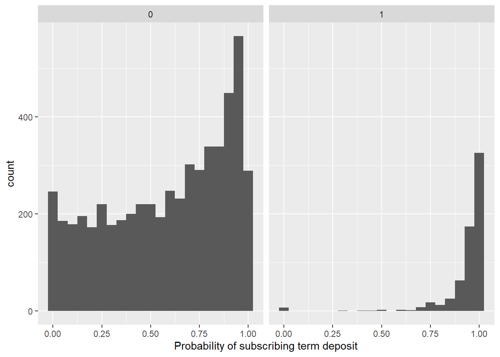

**Interpretations**

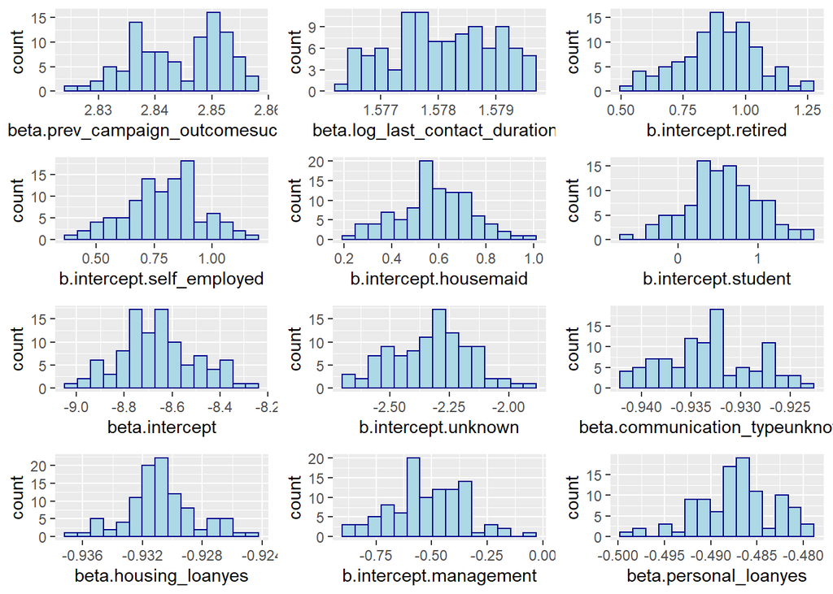

|  | imp_coef |
| --- | --- |
| beta.prev_campaign_outcomesuccess | 2.8442366 |
| beta.log_last_contact_duration | 1.5780833 |
| b.intercept.retired | 0.8933200 |
| b.intercept.self_employed | 0.7918814 |
| b.intercept.housemaid | 0.5841061 |
| b.intercept.student | 0.5676194 |
| beta.intercept | -8.6604417 |
| b.intercept.unknown | -2.3278673 |
| beta.communication_typeunknown | -0.9331713 |
| beta.housing_loanyes | -0.9308010 |
| b.intercept.management | -0.5178354 |
| beta.personal_loanyes | -0.4872836 |

Based on the chain distribution, we can infer that only Job-type: Student variable can not be significant as 0 lies well within the distribution range, but rest of the other variables in the table above can be considered as statistically significant. The high intercept value indicates that by default the probability of subscribing the term deposit will be lower, and it could increase significantly for the following cases –

1. if the outcome of previous campaign with the customer is positive
2. current campaign contact duration was high
3. if the customer is retired, self-employed, housemaid or a student

Similarly, the probability of the customer subscribing the term deposit will go down for the following cases –

1. if job type is unknown or management
2. if the communication channel is unknown for the campaign
3. if the customer already has a housing or a personal loan